← Eğitim Listesine Geri Dön

# Örneklem

2025-05-17

örneklem istatistik veri toplama

# 📊 Örneklem: Ana Kütledeki Gizli Hikâyeyi Anlamak İçin Bir Pencere

## Giriş: Bütünü Görmek Her Zaman Mümkün Değil!

Bazen bir pastanın tadını anlamak için tüm pastayı yemezsiniz. Tek dilim bile o pastanın neye benzediğini tahmin etmenize yetebilir. İşte tam da bu yüzden araştırmalarda da **örneklem** kullanılır.

Ana kütlenin temsili grubudur.

## 🔍 Örneklem Nedir?

**Örneklem** , bir araştırma için incelenmesi amaçlanan **ana kütlenin temsilci grubudur** . Yani aslında bütünden alınan küçük ama bilgi açısından zengin bir parçadır.

### 💡 Örnek:

Türkiye’deki gençlerin sosyal medya alışkanlıklarını incelemek istiyorsunuz. 80 milyon kişiyi tek tek sormak yerine, doğru yöntemle seçilen birkaç bin kişiyle çalışmak yeterlidir. İşte bu birkaç bin kişi, örneklemdir.

## 🧾 Tamsayım Nedir?

Eğer ana kütledeki **her bireye ulaşılıp veri toplanıyorsa** , buna **tamsayım** denir. En meşhur tamsayım örneği tabii ki **nüfus sayımıdır** .

Ama her zaman mümkün değildir. Çünkü…

## ⚖️ Neden Örneklem Kullanılır?

1. **Ana kütleyi incelemek çok zaman alır.**

   > 70 milyon kişiye anket göndermek, yıllarınızı alabilir.
2. **Maliyet açısından pahalıdır.**

   > Herkese ulaşmak, veri girişi yapmak, analiz etmek… Hepsi ciddi kaynak ister.
3. **Her zaman mümkün olmayabilir.**

   > Kimileri yanıt vermeyebilir, bazıları ulaşılamaz olabilir.

## ✅ İyi Bir Örneklemin Özellikleri

Bir örneklemin iyi olması için bazı şartları taşıması gerekir:

1. **Eşit aralıklı ve rastgele seçilmesi gerekir.**

   > Herkesin seçilme şansı eşit olmalı. Yoksa sonuçlar çarpık çıkar.
2. **Ana kütleyi net olarak yansıtmaz.**

   > Ne kadar iyi seçilirse seçilsin, örneklem asla %100 temsiliyet sağlayamaz. Bu nedenle hata payı vardır.
3. **Örneklem büyüdükçe maliyet artar.**

   > Daha fazla kişi = daha fazla harcama = daha uzun süre. Bu dengeleri kurmak önemlidir.
4. **Hata payı genelde %5 ve altında olmalıdır.**

   > Bu, güven aralığımızı belirler. %95 güven düzeyinde çalışmak yaygındır.

## 🎯 Örneklemin Türleri

Örneklemler ikiye ayrılır:

### 1. **Olasılığa Dayalı Teknikler (Rastlantısal Seçim)**

Bu tekniklerde her bireyin seçilme şansı bellidir. Bilimsel çalışmalarda tercih edilir.

- **Basit Tesadüfi Örnekleme:** Rastgele isim çeker gibi.
- **Sistematik Örnekleme:** Belli aralıklarla seçim yapılır. Örneğin her 10 kişiden biri.
- **Tabakalı Örnekleme:** Ana kütleye göre gruplar oluşturulup her gruptan orantılı seçim yapılır.
- **Küme Örnekleme:** Büyük gruplar halinde seçim yapılır. Özellikle coğrafi çalışmalarda kullanılır.

### 2. **Olasılığa Dayalı Olmayan Teknikler (Seçici Yaklaşım)**

Burada seçim keyfi olabilir, amaç yöneliktir. Genellikle nitel araştırmalarda kullanılır.

- **Kolayda Örnekleme:** Ulaşılması kolay olan kişilerle çalışılır.
- **Kasti Örnekleme:** Araştırmacı amaca göre bireyleri seçer.
- **Kota Örnekleme:** Belirlenen özellikler doğrultusunda sınırlı sayıda kişi seçilir.
- **Kartopu Örnekleme:** Katılımcılar kendileri yeni katılımcılar önerir.

## 🧠 Özetle;

| Konu | Açıklama |
| --- | --- |
| **Örneklem** | Ana kütleden seçilen küçük ama temsilci grup |
| **Tamsayım** | Tüm ana kütleye ulaşma süreci |
| **Neden Kullanılır?** | Zaman, maliyet ve uygulanabilirlik nedeniyle |
| **İyi Örneklem** | Rastgele, temsilci, uygun boyutta olmalı |
| **Hata Payı** | Genelde %5 civarı olmalı |
| **Çeşitleri** | Olasılığa dayalı ve dayalı olmayanlar |

## 🎯 Veri Bilimcinin İpucu

> “Veri biliminde önemli olan, çok veri toplamak değil, **doğru veri** toplamaktır.”

```python
import random
import numpy as np

# Diyelim ki 10.000 kişinin aylık alışveriş harcamalarından oluşan bir ana kütlemiz var.
```

```python
# Ana kütleyi oluşturalım (10.000 kişi)
ana_kitle = [random.gauss(350, 100) for _ in range(10000)]  # Ortalama 350 TL, std sapma 100

# Ana kütle ortalamasını hesaplayalım
ana_kitle_ortalama = np.mean(ana_kitle)

print(f"Ana kütle ortalaması: {ana_kitle_ortalama:.2f} TL")
```

```
Ana kütle ortalaması: 349.75 TL
```

```python
# Şimdi bu ana kütleden basit tesadüfi örneklem alalım. Diyelim ki 500 kişilik bir örneklem alıyoruz.

# Basit tesadüfi örneklem alma
orneklem = random.sample(ana_kitle, 500)

# Örneklem ortalamasını hesaplayalım
orneklem_ortalama = np.mean(orneklem)

print(f"Örneklem ortalaması: {orneklem_ortalama:.2f} TL")
```

```
Örneklem ortalaması: 344.92 TL
```

```python
# Artık hem ana kütle hem de örneklem ortalamasını elde ettik. Peki aradaki fark ne kadar?

fark = abs(ana_kitle_ortalama - orneklem_ortalama)
print(f"İki ortalama arasındaki fark: {fark:.2f} TL")
```

```
İki ortalama arasındaki fark: 4.83 TL
```

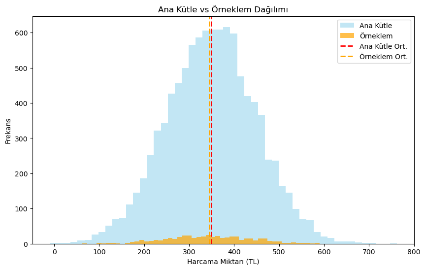

```python
# matplotlib ile dağılımları da görselleştirelim.

import matplotlib.pyplot as plt

plt.figure(figsize=(10,6))

# Ana kütle histogramı
plt.hist(ana_kitle, bins=50, alpha=0.5, label="Ana Kütle", color="skyblue")

# Örneklem histogramı
plt.hist(orneklem, bins=50, alpha=0.7, label="Örneklem", color="orange")

plt.axvline(ana_kitle_ortalama, color='red', linestyle='dashed', linewidth=2, label='Ana Kütle Ort.')
plt.axvline(orneklem_ortalama, color='orange', linestyle='dashed', linewidth=2, label='Örneklem Ort.')

plt.title("Ana Kütle vs Örneklem Dağılımı")
plt.xlabel("Harcama Miktarı (TL)")
plt.ylabel("Frekans")
plt.legend()
plt.show()
```

## 🎯 Özet

Bu uygulamada şunları öğrendik:

| Aşama | Açıklama |
| --- | --- |
| Ana kütle oluşturma | 10.000 kişinin harcama verisi üretildi |
| Örneklem alma | 500 kişilik rastgele örneklem seçildi |
| Ortalama karşılaştırması | Örneklem ortalaması ana kütleye oldukça yakın çıktı |
| Görselleştirme | Histogram ile dağılım karşılaştırıldı |